# Exploratory Analysis of Text Data for Predictive Modeling

Mohammed Teslim

2025-01-18

## Introduction

This report summarizes the initial exploration of a large text dataset that will be used to build a predictive text application, similar to the auto-complete feature found on many smartphones. The goal of this application is to predict the next word a user is likely to type, based on the preceding words they have entered.

## Data Source

The data consists of text collected from three different sources:

- **Blogs:** Entries from personal blogs.
- **News:** Articles from news websites.
- **Twitter:** Posts from the social media platform Twitter.

These three sources represent a diverse range of writing styles and topics, which is important for building a robust and versatile prediction model.

## Data Summary

A preliminary analysis of the data reveals the following key statistics:

| File | Lines | Words | Unique_Words |
| --- | --- | --- | --- |
| Blogs | 899288 | 37334131 | 1103548 |
| News | 77259 | 2643969 | 197858 |
| Twitter | 2360148 | 30373583 | 1290173 |

## Word Frequency Analysis

An analysis of word frequencies reveals that a small number of words account for a large proportion of the text. This is a common characteristic of natural language.

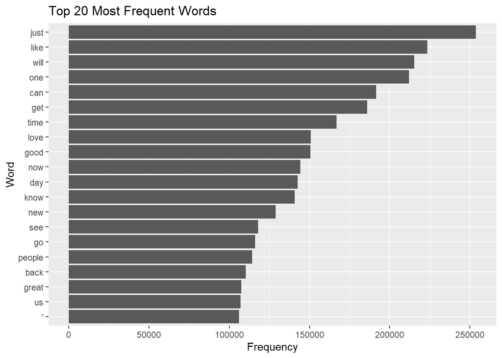

**Histogram of Top 20 Most Frequent Words**

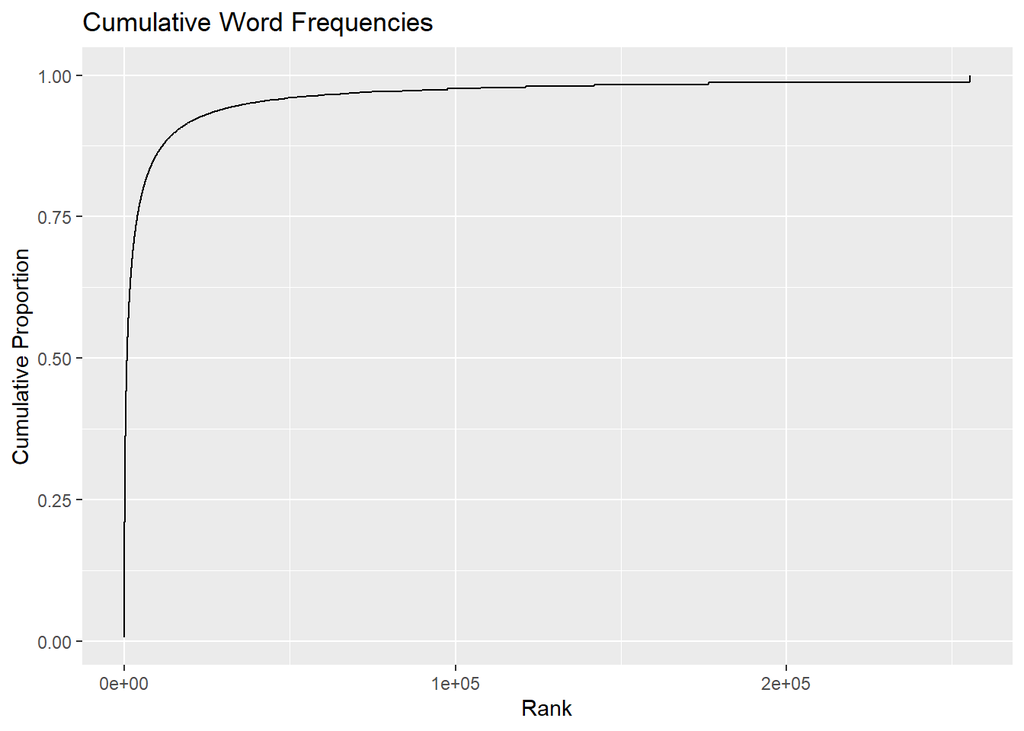

**Cumulative Word Coverage**

The plot above illustrates how many unique words are needed to cover a certain percentage of all word occurrences in the text.

```
## Words needed to cover 50% of instances: 804
```

```
## Words needed to cover 90% of instances: 15472
```

This finding suggests that we can potentially build a smaller and more efficient prediction model by focusing on the most frequent words.

## N-gram Analysis (Word Combinations)

In addition to individual words, we also analyzed common combinations of 2 words (bigrams) and 3 words (trigrams).

| feature | frequency |
| --- | --- |
| right_now | 21735 |
| last_night | 14534 |
| ’_s | 11362 |
| feel_like | 11293 |
| looking_forward | 10724 |

| feature | frequency |
| --- | --- |
| let_us_know | 2444 |
| happy_new_year | 1882 |
| happy_mothers_day | 1734 |
| happy_mother’s_day | 1638 |
| new_york_city | 1257 |

**Top 5 Most Frequent Bigrams**

The table above shows the 5 most frequent bigrams and their counts.

**Top 5 Most Frequent Trigrams**

The table above shows the 5 most frequent trigrams and their counts.

These common word combinations are essential for building a model that can accurately predict the next word in a sequence.

## Plan for Prediction Algorithm and Shiny App

### Algorithm

The core of the prediction algorithm will be an **n-gram model**. This model calculates the probability of a word appearing, given the previous n-1 words (the context). We will use a combination of quadgrams (4 words), trigrams (3 words), bigrams (2 words), and unigrams (single words) to make predictions.

A technique called **backoff** will be used to handle cases where a particular word combination is not found in the training data. In such cases, the model will “back off” to a lower-order n-gram (e.g., from a trigram to a bigram) to make a prediction.

### Shiny App

The prediction algorithm will be deployed as a user-friendly web application using the **Shiny** framework. The app will have a simple interface:

1. A text input box where the user can type.
2. A display area that shows the top 3 predicted words in real time.

### Efficiency Considerations

To ensure a responsive user experience, the model will be optimized for both size and speed:

- **Reduced Vocabulary:** The model will focus on the most frequent words to minimize memory usage.
- **Efficient Data Structures:** We will use optimized data structures (like `data.table`) for storing and retrieving n-gram probabilities.
- **Pre-computation:** As much as possible, calculations will be pre-computed and stored to reduce prediction time.